# EffLen Design Matrix

Hillary Heiling

February 6, 2020

# Overview

Goal: Document the steps used to perform the following tasks:

- Isolate approx. 5,000 genes to use for upcoming simulations based on UCLA data.
- Fit “realistic” Dirichlet distribution for these 5,000
- Filter gene clusters for clusters with desired criteria (only one gene per cluster, gene has 3+ isoforms …) and sample 1000 gene clusters from the results
- Find possible exon sets and create string labels for each set modeled after the labels given to exon sets in the `countReads()` output (isoform package). (For 1000 genes of interest)
- Calculate effective length design matrix for possible exon sets. (For 1000 genes of interest)

# Needed libraries and materials:

```r
library(stringr)
library(gtools)

# Load IsoDeconvMM library:
# library(remotes)
# install_github("hheiling/IsoDeconvMM", force = TRUE)
library(IsoDeconvMM)

# Load isoAll object form knownIsoforms file
load("Human_Materials/Homo_sapiens.GRCh37.66.nonoverlap.exon.knownIsoforms.RData")
# Load the nTE object
load("Human_Materials/Homo_sapiens.GRCh37.66.nTE.RData")
# Load the eDat object
eDat = readRDS("Human_Materials/ucla_eDat.rds")
```

# Gene Clusters of Interest

First, from the nTE information, sample gene clusters where there is only one gene per cluster. Subset the eDat UCLA data based on this sampling.

Using the eDat information from the UCLA data summary output, select genes with the following qualities:

Examine materials of interest: UCLA eDat object, nTE object

```r
# Examine eDat information provided
dim(eDat)
```

```
## [1] 57820    89
```

```r
# head(rownames(eDat),10) # gene names
# head(colnames(eDat),10) # sample ID
eDat[1:5, 1:5]
```

```
##                    UMB5558_ba9 UMB5391_ba9 UMB5342_ba9_2nd UMB5340_ba9_2nd
## ENSG00000000003.10       95.00      108.00           87.00          208.00
## ENSG00000000005.5         4.00        2.00            3.00            5.00
## ENSG00000000419.8       135.00      275.00          191.00          540.00
## ENSG00000000457.9       113.22      247.26          323.28          578.72
## ENSG00000000460.12       36.78       58.74           53.72          135.28
##                    UMB5309_ba9
## ENSG00000000003.10       90.00
## ENSG00000000005.5         1.00
## ENSG00000000419.8       148.00
## ENSG00000000457.9       203.79
## ENSG00000000460.12       60.21
```

```r
# Examine initial nTE information provided
head(nTE, 20)
```

```
##             geneId  nE nT clustID
## 1  ENSG00000000003  29  4  chrX_1
## 2  ENSG00000000005  10  2  chrX_2
## 3  ENSG00000000419  72  8 chr20_1
## 4  ENSG00000000457  63  5  chr1_1
## 5  ENSG00000000460 150 10  chr1_1
## 6  ENSG00000000938  85  9  chr1_2
## 7  ENSG00000000971  72  7  chr1_3
## 8  ENSG00000001036  16  4  chr6_1
## 9  ENSG00000001084  72 12  chr6_2
## 10 ENSG00000001167  19  2  chr6_3
## 11 ENSG00000001460  88 15  chr1_4
## 12 ENSG00000001461  62  8  chr1_5
## 13 ENSG00000001497  67  6  chrX_3
## 14 ENSG00000001561   8  2  chr6_4
## 15 ENSG00000001617  87  9  chr3_1
## 16 ENSG00000001626  93  7  chr7_1
## 17 ENSG00000001629  47  7  chr7_2
## 18 ENSG00000001630  40  6  chr7_3
## 19 ENSG00000001631 215 25  chr7_4
## 20 ENSG00000002016 176 23 chr12_1
```

Summary of UCLA eDat object: Total number of genes provided in the UCLA eDat information: 57,820 genes. Total number of samples present in the UCLA eDat information: 89 samples. Values within eDat information: expected gene counts. If of interest, see “Human_Materials/step2_check_RSEM_ucla.R” file for further information about how this eDat object was created.

For later coding convenience purposes, remove genes from consideration that belong to a transcript cluster that contains 2 or more genes (based this information off of nTE information).

```r
library(stringr)

all_genes = str_split_fixed(rownames(eDat), "\\.", n = 2)

# Identify clusters with only one gene
clustID_table = table(nTE$clustID)
clustID_singular = which(clustID_table == 1)
nTE_A = nTE[which(nTE$clustID %in% names(clustID_singular)),]

# Check that selection of cluster worked properly
for(clust in nTE_A$clustID){
  gene = nTE[which(nTE$clustID == clust),1]
  if(length(gene) > 1){
    cat("problem clust: ", clust, "\n")
  }
}

# Subset eDat object to genes within these chosen clusters
eDat_subsetA = eDat[which(all_genes[,1] %in% nTE_A$geneId),]

dim(eDat_subsetA)
```

```
## [1] 38851    89
```

Total remaining genes after single gene cluster filtering step: 38,851 genes.

Next, remove genes from consideration that have generally low expression across the 89 samples.

```r
select_gene = function(x){
  q75 = quantile(x, prob = 0.75)
  if(q75 > 30){
    return(1)
  }else{
    return(0)
  }
}

keep = apply(eDat_subsetA, 1, function(x) select_gene(x))
sum(keep)
```

```
## [1] 10414
```

```r
eDat_subsetB = eDat_subsetA[which(keep == 1),]
genes_B = str_split_fixed(rownames(eDat_subsetB), "\\.", n = 2)
nTE_B = nTE_A[which(nTE_A$geneId %in% genes_B[,1]),]
dim(eDat_subsetB)
```

```
## [1] 10414    89
```

```r
dim(nTE_B)
```

```
## [1] 10414     4
```

Total remaining genes after low expression filtering step: 10,414 genes.

Our goal is to fit a Dirichlet distribution to these genes. However, the Dirichlet fit algorithm used in this process (`DirichReg` function from `DirichletReg` R package) is computationally limited by the number of genes and has issues fitting a Dirichlet distribution to over 10,000 genes. Therefore, we will pick genes from a subset of chromosomes such that the total gene count is closer to 5,000 genes.

```r
# Non-sex chromosomes: chromosomes 1 to 22
num_genes = numeric(22)

# Number of genes from subsetted nTE_A object in these chromosomes
for(i in 1:22){
  num_genes[i] = sum(str_detect(nTE_B$clustID, sprintf("chr%i_",i)))
}

# Examine chromosome summary
(num_genesDF = data.frame(chr = str_c("chr",1:22), num_genes = num_genes,
                          cumsum = cumsum(num_genes)))
```

```
##      chr num_genes cumsum
## 1   chr1      1075   1075
## 2   chr2       674   1749
## 3   chr3       573   2322
## 4   chr4       425   2747
## 5   chr5       489   3236
## 6   chr6       561   3797
## 7   chr7       528   4325
## 8   chr8       374   4699
## 9   chr9       473   5172
## 10 chr10       444   5616
## 11 chr11       493   6109
## 12 chr12       467   6576
## 13 chr13       213   6789
## 14 chr14       273   7062
## 15 chr15       288   7350
## 16 chr16       327   7677
## 17 chr17       619   8296
## 18 chr18       201   8497
## 19 chr19       839   9336
## 20 chr20       294   9630
## 21 chr21        98   9728
## 22 chr22       215   9943
```

```r
# Select chromosoms 1-9 to consider approx. 5,000 genes
nTE_C = nTE_B[c(which(str_detect(nTE_B$clustID, "chr1_")),
                which(str_detect(nTE_B$clustID, "chr2_")),
                which(str_detect(nTE_B$clustID, "chr3_")),
                which(str_detect(nTE_B$clustID, "chr4_")),
                which(str_detect(nTE_B$clustID, "chr5_")),
                which(str_detect(nTE_B$clustID, "chr6_")),
                which(str_detect(nTE_B$clustID, "chr7_")),
                which(str_detect(nTE_B$clustID, "chr8_")),
                which(str_detect(nTE_B$clustID, "chr9_"))),]

dim(nTE_C)
```

```
## [1] 5172    4
```

```r
# Subset eDat_subsetB to include just the genes selected in the above filtering steps
eDat_subsetC = eDat_subsetB[which(genes_B[,1] %in% nTE_C$geneId),]

dim(eDat_subsetC)
```

```
## [1] 5172   89
```

Based on the above information, we chose genes belonging to chromosomes 1 to 9, resulting in 5,172 genes total used for the simulation.

Now, we will fit a Dirichlet distribution to these genes.

```r
# Use counts in eDat_subset to fit a Dirichlet distribution for these genes

# install.packages("DirichletReg")
library(DirichletReg)

# Convert eDat_subset matrix to rows = observations, cols = genes
Y_counts = t(eDat_subsetC)
Y_norm = Y_counts / rowSums(Y_counts)
Y = DR_data(Y_norm, trafo = T)

# fit intercept-only model
gene_dir = DirichReg(formula = Y ~ 1, data = NULL, model = "common")
# Extract alpha values from fit
fit_dir = fitted.DirichletRegModel(gene_dir, alpha = T)
# Note: alpha values for a gene same for all observations (just pick a row from alpha output)
gene_alpha = fit_dir$alpha[1,]
```

Save Dirichlet results

```r
library(stringr)

split_names = str_split_fixed(names(gene_alpha), "\\.", n = 2)
gene_names = split_names[,1]
names(gene_alpha) = gene_names

save(gene_alpha, file = "Human_Materials/Dirichlet_UCLA_gene_alpha.RData")
```

Of these approx. 5,000 genes, we want to chose 1,000 genes that will be the focus of the `IsoDeconvMM` fitting algorithm. In very general terms, this `IsoDeconvMM` algorithm utilizes non-overlapping exon set count information to fit isoform parameters for each pure cell type reference sample, and then uses these isoform parameters plus the mixture sample exon set counts to estimate the deconvolution of cell types in the mixture sample. This algorithm works best if it is provided a list a genes with differential expression and/or differential isoform usage.

We want to determine realistic exon set counts for 1,000 genes, chose 100 of these genes to be differentially expressed and a separate 100 to have differential isoform usage, and then specify different selection specifications of these 1,000 genes to the `IsoDeconvMM` algorithm in order to examine power differences.

Therefore, from the nTE information, we will sample 1,000 gene clusters with the following qualities so that they are eligible for differential expression and/or differential isoform usage:

- Only consider clusters where the gene has 3 or more isoforms
- Consider clusters with relatively higher expression within the total of 5,172 genes

```r
# Limit to clusters with 3+ isoforms
nTE_subset = nTE_C[which(nTE_C$nT > 2),]
dim(nTE_subset)
```

```
## [1] 3783    4
```

```r
# Select 'top' genes based on median expression values in the UCLA data
#   and filtering based on 3+ isoforms per gene
q50 = apply(eDat_subsetC, 1, function(x) quantile(x, prob = 0.50))
median_q25 = quantile(q50, prob = 0.25)
gene_options = intersect(nTE_C$geneId[which(q50 > median_q25)],
                         nTE_subset$geneId)
length(gene_options)
```

```
## [1] 2875
```

```r
# Sample 1000 genes from above gene_options
set.seed(19483)
gene_sample = sample(gene_options, size = 1000, replace = F)
nTE_sample = nTE_subset[which(nTE_subset$geneId %in% gene_sample),]

# Order sample by chromosome then cluster number within chromosome
nTE_sample$chr = substr(nTE_sample$clustID, start = 1, stop = 4)
nTE_sample$ID_num = str_remove(nTE_sample$clustID, str_c(nTE_sample$chr,"_"))
nTE_filtered = nTE_sample[order(nTE_sample$chr, as.numeric(nTE_sample$ID_num)),]

# Ending result check:
dim(nTE_filtered)
```

```
## [1] 1000    6
```

```r
head(nTE_filtered, 20)
```

```
##               geneId  nE nT  clustID  chr ID_num
## 11   ENSG00000001460  88 15   chr1_4 chr1      4
## 357  ENSG00000014914 136 13  chr1_29 chr1     29
## 540  ENSG00000036549  78 11  chr1_49 chr1     49
## 737  ENSG00000054392 112 11  chr1_71 chr1     71
## 947  ENSG00000065600  31  5  chr1_95 chr1     95
## 973  ENSG00000066136 191 26 chr1_100 chr1    100
## 1018 ENSG00000067334  26  7 chr1_107 chr1    107
## 1028 ENSG00000067704  58  5 chr1_110 chr1    110
## 1081 ENSG00000069275  15  3 chr1_112 chr1    112
## 1147 ENSG00000070831  38  6 chr1_119 chr1    119
## 1303 ENSG00000075151 295 19 chr1_126 chr1    126
## 1355 ENSG00000076321  35  6 chr1_130 chr1    130
## 1358 ENSG00000076356  44  6 chr1_131 chr1    131
## 1390 ENSG00000077254 165 18 chr1_135 chr1    135
## 1406 ENSG00000077585  31  6 chr1_138 chr1    138
## 1455 ENSG00000078808  39  8 chr1_141 chr1    141
## 1534 ENSG00000081026  98  7 chr1_149 chr1    149
## 1556 ENSG00000081721  21  5 chr1_154 chr1    154
## 1633 ENSG00000084070  40  5 chr1_161 chr1    161
## 1647 ENSG00000084628  32  7 chr1_165 chr1    165
```

```r
save(nTE_filtered, file = "Human_Materials/Homo_sapiens.GRCh37.66.nTE.filtered.RData")
```

A total of 2,875 genes both contained 3 or more isoforms and had relatively higher expression. The 1,000 ‘genes of interest’ were sampled from these 2,875 genes.

# Total Count Scale from UCLA Data

In order to provide a realistic total read count for samples in the upcoming simulation, we used the UCLA data to get an idea of the scale for the total counts of the approx. 5000 genes selected for simulation.

A histogram of the total read counts for these approx. 5,000 genes across the 89 samples in the UCLA data is provided below.

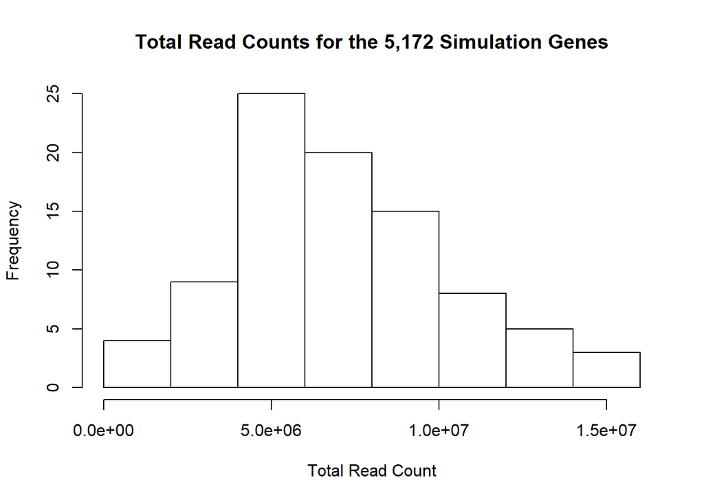

```r
hist(colSums(eDat_subsetC), main = "Total Read Counts for the 5,172 Simulation Genes",
     xlab = "Total Read Count")
```

```r
summary(colSums(eDat_subsetC))
```

```
##     Min.  1st Qu.   Median     Mean  3rd Qu.     Max.
##  1208937  4587701  6492102  7022138  9096560 15110422
```

It appears that the majority of samples have total read counts between approx. 4.5 million and 9 million samples.

Based on the above information, we decided it was appropriate to specify total reads with a normal distribution with mean 7 million and sd 1 million.

# Determining Exon Set Combinations

For the 1,000 ‘genes of interest’ sampled in the section “Gene Clusters of Interest”, we eventually want to simulate exon set counts. In order to do this, we first need to identify possible exon sets. After these possible exon sets have been identifyied, we can calculated the effective lengths for these exon sets and eliminate sets from consideration that have effective lengths of 0 (see “Calculate Effective Length Design Matrices” section later in document).

While it may be a simplification of what can be seen in real data, we decided to limit the possible exon sets to consecutive exon sets of length 1, 2, and 3 total exons. In other words, if an isoform contains the numbered exons 2, 3, 5, and 7, then all possible exon sets would be:

- Singular exon sets: {2}, {3}, {5}, {7}
- Double exon sets: {2,3}, {3,5}, {5,7}
- Triple exon sets: {2,3,5}, {3,5,7}

Below is the code to identify these possible exon sets. The results are stored in the same format that exon sets are recorded in the output from the `countReads` function in the `isoform` R package.

Sample output from `countReads` function (first column counts, second column exons):

```r
head(read.table(file = "Mouse_Materials/mm9_set1_counts.txt"))
```

```
##   V1
## 1  3
## 2  7
## 3 35
## 4  1
## 5  3
## 6  6
##                                                                                                 V2
## 1                                                                  chr1_1000|ENSMUSG00000062963|1;
## 2                                 chr1_1000|ENSMUSG00000062963|10;chr1_1000|ENSMUSG00000062963|11;
## 3                                 chr1_1000|ENSMUSG00000062963|10;chr1_1000|ENSMUSG00000062963|12;
## 4 chr1_1000|ENSMUSG00000062963|10;chr1_1000|ENSMUSG00000062963|12;chr1_1000|ENSMUSG00000062963|14;
## 5  chr1_1000|ENSMUSG00000062963|10;chr1_1000|ENSMUSG00000062963|12;chr1_1000|ENSMUSG00000062963|7;
## 6  chr1_1000|ENSMUSG00000062963|10;chr1_1000|ENSMUSG00000062963|12;chr1_1000|ENSMUSG00000062963|9;
```

Possible exon set identification:

```r
# Extract exon set information for gene clusters of interest

exon_sets = list()

for(clust in nTE_filtered$clustID){

  # Extract non-overlapping exon vs isoform matrix
  candiIsoform = isoAll[[clust]]
  iso_names = colnames(candiIsoform)
  # Extract gene information for each cluster
  gene = nTE_filtered[which(nTE_filtered$clustID == clust),1]

  if(length(gene) > 1){
    cat("clust with too many genes: ", clust, "\n")
  }

  # Total isoforms
  iso_total = ncol(candiIsoform)

  sets1 = as.character(NULL)
  sets2 = as.character(NULL)
  sets3 = as.character(NULL)

  for(j in 1:iso_total){
    # Identify exons that appear in isoform j
    subset_exons = as.character(which(candiIsoform[,j] == 1))
    num_exons = length(subset_exons)

    single_sets = str_c(clust, "|", gene, "|", subset_exons, ";")

    if(num_exons > 1){
      double_sets = character(num_exons - 1)
      for(e in 1:(num_exons - 1)){
        double_sets[e] = str_c(single_sets[e], single_sets[e+1])
      }
    }else{
      double_sets = NULL
    }

    if(num_exons > 2){
      triple_sets = character(num_exons - 2)
      for(e in 1:(num_exons - 2)){
        triple_sets[e] = str_c(single_sets[e], single_sets[e+1], single_sets[e+2])
      }
    }else{
      triple_sets = NULL
    }

    sets1 = union(sets1, single_sets)
    sets2 = union(sets2, double_sets)
    sets3 = union(sets3, triple_sets)

  }

  # sets_all = list(single_sets = sets1, double_sets = sets2, triple_sets = sets3)

  sets_all = c(sets1, sets2, sets3)

  exon_sets[[clust]] = list(candiIsoform = candiIsoform, sets = sets_all)

}

# Examine output
head(exon_sets$chr1_4$sets, 10)
```

```
##  [1] "chr1_4|ENSG00000001460|1;"  "chr1_4|ENSG00000001460|2;"
##  [3] "chr1_4|ENSG00000001460|3;"  "chr1_4|ENSG00000001460|4;"
##  [5] "chr1_4|ENSG00000001460|5;"  "chr1_4|ENSG00000001460|6;"
##  [7] "chr1_4|ENSG00000001460|7;"  "chr1_4|ENSG00000001460|12;"
##  [9] "chr1_4|ENSG00000001460|13;" "chr1_4|ENSG00000001460|14;"
```

```r
tail(exon_sets$chr1_4$sets, 10)
```

```
##  [1] "chr1_4|ENSG00000001460|15;chr1_4|ENSG00000001460|16;chr1_4|ENSG00000001460|17;"
##  [2] "chr1_4|ENSG00000001460|20;chr1_4|ENSG00000001460|21;chr1_4|ENSG00000001460|22;"
##  [3] "chr1_4|ENSG00000001460|21;chr1_4|ENSG00000001460|22;chr1_4|ENSG00000001460|23;"
##  [4] "chr1_4|ENSG00000001460|22;chr1_4|ENSG00000001460|23;chr1_4|ENSG00000001460|24;"
##  [5] "chr1_4|ENSG00000001460|21;chr1_4|ENSG00000001460|22;chr1_4|ENSG00000001460|26;"
##  [6] "chr1_4|ENSG00000001460|26;chr1_4|ENSG00000001460|27;chr1_4|ENSG00000001460|37;"
##  [7] "chr1_4|ENSG00000001460|26;chr1_4|ENSG00000001460|27;chr1_4|ENSG00000001460|29;"
##  [8] "chr1_4|ENSG00000001460|27;chr1_4|ENSG00000001460|29;chr1_4|ENSG00000001460|30;"
##  [9] "chr1_4|ENSG00000001460|29;chr1_4|ENSG00000001460|30;chr1_4|ENSG00000001460|31;"
## [10] "chr1_4|ENSG00000001460|25;chr1_4|ENSG00000001460|26;chr1_4|ENSG00000001460|27;"
```

```r
length(exon_sets$chr1_4$sets)
```

```
## [1] 141
```

For the remaining 4,172 genes that are not the 1,000 ‘genes of interest’, these genes primary function are to contribute to a realistic distribution of gene counts. Therefore, we only need to calculate a realistic gene count for each of these genes. However, in the counts files to be simulated, the output must be stored in exon set counts. Unlike the 1,000 genes of interest, though, we don’t necessarily care about the distribution of counts across isoforms and specific exon sets because these gene clusters will not be used in the `IsoDeconvMM` fit algorithm, so we only care about the total gene count.

In order to cut down on unnecessary computation, we can arbitrarily distribute the count for a gene approx. uniformly across the singular exon sets for a gene. As a result, the counts files simulated will still contain realistic total read counts, and this unrealistic distribution across exon sets will go unnoticed by the fit algorithm since none of these genes will be selected for isoform parameter calculations.

Consequently, for these genes, we will only singluar exon sets (i.e. sets {2}, {3}, {5}, and {7} from the example described earlier).

```r
# Extract exon set information for gene clusters of interest

nTE_other = nTE_C[-which(nTE_C$geneId %in% nTE_filtered$geneId),]
dim(nTE_other)
```

```
## [1] 4172    4
```

```r
dim(nTE_C)
```

```
## [1] 5172    4
```

```r
dim(nTE_filtered)
```

```
## [1] 1000    6
```

```r
exon_sets_other = list()

for(clust in unique(nTE_other$clustID)){

  # Extract non-overlapping exon vs isoform matrix
  candiIsoform = isoAll[[clust]]
  iso_names = colnames(candiIsoform)
  # Extract gene information for each cluster
  gene = nTE_other[which(nTE_other$clustID == clust),1]

  if(length(gene) > 1){
    cat("clust with too many genes: ", clust, "\n")
  }

  # Total isoforms
  iso_total = ncol(candiIsoform)

  sets1 = as.character(NULL)

  for(j in 1:iso_total){
    # Identify exons that appear in isoform j
    subset_exons = as.character(which(candiIsoform[,j] == 1))
    num_exons = length(subset_exons)

    single_sets = str_c(clust, "|", gene, "|", subset_exons, ";")

    sets1 = union(sets1, single_sets)

  }

  exon_sets_other[[clust]] = sets1

}

# Examine output
head(exon_sets_other$chr1_2, 10)
```

```
##  [1] "chr1_2|ENSG00000000938|1;"  "chr1_2|ENSG00000000938|2;"
##  [3] "chr1_2|ENSG00000000938|3;"  "chr1_2|ENSG00000000938|4;"
##  [5] "chr1_2|ENSG00000000938|5;"  "chr1_2|ENSG00000000938|6;"
##  [7] "chr1_2|ENSG00000000938|7;"  "chr1_2|ENSG00000000938|8;"
##  [9] "chr1_2|ENSG00000000938|9;"  "chr1_2|ENSG00000000938|11;"
```

```r
tail(exon_sets_other$chr1_2, 10)
```

```
##  [1] "chr1_2|ENSG00000000938|28;" "chr1_2|ENSG00000000938|29;"
##  [3] "chr1_2|ENSG00000000938|23;" "chr1_2|ENSG00000000938|24;"
##  [5] "chr1_2|ENSG00000000938|25;" "chr1_2|ENSG00000000938|21;"
##  [7] "chr1_2|ENSG00000000938|10;" "chr1_2|ENSG00000000938|26;"
##  [9] "chr1_2|ENSG00000000938|17;" "chr1_2|ENSG00000000938|18;"
```

```r
length(exon_sets_other$chr1_2)
```

```
## [1] 29
```

```r
other_geneInfo = list(nTE_other = nTE_other, exon_sets_other = exon_sets_other)

save(other_geneInfo, file = "Human_Materials/Homo_sapiens.GRCh37.66.other.geneInfo.RData")
```

# Created Files Necessary for Effective Length Calculations

The calculation of effective lengths requires a list of exon sets for consideration (realistic counts not required), a distribution of the fragment lengths (the lengths of fragments and frequency of these lengths), and various other information including exons making up isoforms for genes and exon lengths.

The list of exon sets and the fragment length distribution must be created in this document (see following subsections). The remaining materials are already available in the “Human_Materials” folder (the BED file and the knownIsoforms object).

## “Mock” count .txt file

Using the exon sets created in section “Determining Exon Set Combinations” for the 1,000 genes of interest, create a mock count data .txt file in the same format as count files created by countReads() isoform package function. Only the exon sets are important for this step, so each exon set is given an arbitrary non-zero count.

```r
exon_vec = as.character(NULL)
for(clust in names(exon_sets)){
  exon_vec = c(exon_vec, exon_sets[[clust]]$sets)
}

head(exon_vec, 20)

# Sample random counts for each exon set - place-holder counts only, not official simulated counts
# cts = sample(2:8, size = length(exon_vec), replace = T)

# Give each exon set an arbitrary count value
cts = rep(1, times = length(exon_vec))

mock_counts = data.frame(cts, exon_vec)
```

[output not shown]

```r
write.table(mock_counts, file = "Human_Materials/mock_counts.txt", col.names = F, row.names = F)
```

Examine mock counts output

```r
cts_fake = read.table("Human_Materials/mock_counts.txt", as.is = T)

head(cts_fake, 20)
```

```
##    V1                         V2
## 1   1  chr1_4|ENSG00000001460|1;
## 2   1  chr1_4|ENSG00000001460|2;
## 3   1  chr1_4|ENSG00000001460|3;
## 4   1  chr1_4|ENSG00000001460|4;
## 5   1  chr1_4|ENSG00000001460|5;
## 6   1  chr1_4|ENSG00000001460|6;
## 7   1  chr1_4|ENSG00000001460|7;
## 8   1 chr1_4|ENSG00000001460|12;
## 9   1 chr1_4|ENSG00000001460|13;
## 10  1 chr1_4|ENSG00000001460|14;
## 11  1 chr1_4|ENSG00000001460|16;
## 12  1 chr1_4|ENSG00000001460|17;
## 13  1 chr1_4|ENSG00000001460|19;
## 14  1 chr1_4|ENSG00000001460|22;
## 15  1 chr1_4|ENSG00000001460|26;
## 16  1 chr1_4|ENSG00000001460|27;
## 17  1 chr1_4|ENSG00000001460|35;
## 18  1 chr1_4|ENSG00000001460|28;
## 19  1 chr1_4|ENSG00000001460|32;
## 20  1 chr1_4|ENSG00000001460|23;
```

## Simulate “Mock” Fragment Length Distribution

Assumption: Can use the same effective length design matrices calculated here for all simulated data.

For this mock example, assume total read counts are 20 million, and the distribution of lengths is normally distributed with mean 300 and sd 50. (Total number of 20 million isn’t of much relevance, just need enough samples to get a good idea of the fragment length distribution, the mean and sd of which will be consistent across simulated samples).

We will assume that the simulated counts are based on paired-end reads with read length of 75. Therefore, the minimum read length should be 150. We will also consider the maximum read length to be no larger than 600, which is reasonable given the specified length distribution.

```r
library(Rcpp)
library(RcppArmadillo)
sourceCpp("geneModel_code/fragLens_dist.cpp")

fragLens_out = function(total_reads = 2*10^7, mean = 300, SD = 50, lenMin = 150, lenMax = 600,
                        out_file){
  # fragLens_dist() in geneModel_code/fragLens_dist.cpp file
  freq_dist = fragLens_dist(total_reads, mean, SD, lenMin, lenMax)
  freq_dist = freq_dist[which(freq_dist[,1] > 0),]
  write.table(freq_dist, file = out_file, col.names = F, row.names = F)
}

set.seed(3860)
fragLens_out(total_reads = 2*10^7, mean = 300, SD = 50, lenMin = 150, lenMax = 600,
             out_file = "Human_Materials/mock_fraglens.txt")
```

View fraglens.txt output

```r
fl_dist = read.table("Human_Materials/mock_fraglens.txt", as.is = T)
fl_dist
```

```
##         V1  V2
## 1    27715 150
## 2     1909 151
## 3     1995 152
## 4     2142 153
## 5     2258 154
## 6     2361 155
## 7     2541 156
## 8     2689 157
## 9     2929 158
## 10    2992 159
## 11    3221 160
## 12    3364 161
## 13    3535 162
## 14    3717 163
```

[output cut: 390 more lines]

```r
sum(fl_dist[,1])
```

```
## [1] 20000000
```

```r
summary(fl_dist)
```

```
##        V1               V2
##  Min.   :     1   Min.   :150.0
##  1st Qu.:  1568   1st Qu.:250.8
##  Median : 21145   Median :351.5
##  Mean   : 49505   Mean   :351.6
##  3rd Qu.: 95389   3rd Qu.:452.2
##  Max.   :159981   Max.   :567.0
```

```r
sum(fl_dist[,1]*fl_dist[,2]) / sum(fl_dist[,1])
```

```
## [1] 300.0211
```

```r
fl_dist[1,1] / sum(fl_dist[,1])
```

```
## [1] 0.00138575
```

# Calculate Effective Length Design Matrices

In this section, the effective length design matrix (used for later simulations) of the 1,000 ‘genes of interest’ is calculated. The rows of this ultimate design matrix correspond to exon sets, and the columns of the matrix correspond to the possible isoforms for the gene.

During the procedure to calculate this design matrix, exon sets (rows of the X matrix) are eliminated from consideration if the entire row gives a 0 effective length for all isoforms. After this exon set elimination, if there are entries where the effective length is a fraction between 0 adn 1, then the effective length for this entry is rounded up to 1.

The output is a list with a list element for each cluster. For each cluster, the effective length design matrix (X), the names of the exon sets that have an effective length of 1 for at least one isoform (ExonSetLabels), the knownIsoforms information for the cluster (candiIsoform, see knownIsoforms description in `IsoDeconvMM()` function documentation in the `IsoDeconvMM` package), and information about exon lengths (info) are provided.

Source code files used to calculate effective length design matrix X:

```r
code_files = c("IsoDeconv_Step1.R","dev_compiled_geneMod2.R","geneModel_X.R")
for(f in code_files){
  source(sprintf("geneModel_code/%s",f))
}
```

Run code:

```r
prefix = getwd()

X_info = IsoDeconv_Step1(directory = sprintf("%s/Human_Materials", prefix),
                         mix_files = "mock_counts.txt",
                         pure_ref_files = matrix(c("mock_counts.txt","fake"), nrow = 1),
                         fraglens_files = "mock_fraglens.txt",
                         bedFile = "Homo_sapiens.GRCh37.66.nonoverlap.exon.bed",
                         knownIsoforms= "Homo_sapiens.GRCh37.66.nonoverlap.exon.knownIsoforms.RData",
                         discrim_genes = nTE_filtered$geneId,
                         readLen = 75, lmax = 600, eLenMin = 0)
```

Save results

```r
save(X_info, file = "Human_Materials/Effective Length Design Matrices.RData")
```

Examination of output:

```r
# Load the effective length info
load(file = "Human_Materials/Effective Length Design Matrices.RData")
# Number of clusters selected
length(X_info)
```

```
## [1] 1000
```

```r
# clusters considered
head(names(X_info))
```

```
## [1] "chr1_100"  "chr1_1000" "chr1_1013" "chr1_1014" "chr1_1034" "chr1_1037"
```

```r
# Names of output per cluster
names(X_info$chr1_100)
```

```
## [1] "info"          "candiIsoform"  "X"             "exon_sets"
## [5] "ExonSetLabels"
```

```r
# Examination of output for a sample cluster
head(X_info$chr1_100$info)
```

```
##    chr    start      end            gene exon
## 1 chr1 41157319 41157357 ENSG00000066136    1
## 2 chr1 41157357 41157360 ENSG00000066136    2
## 3 chr1 41157360 41157380 ENSG00000066136    3
## 4 chr1 41157380 41157387 ENSG00000066136    4
## 5 chr1 41157387 41157414 ENSG00000066136    5
## 6 chr1 41157414 41157470 ENSG00000066136    6
```

```r
head(X_info$chr1_100$candiIsoform)
```

```
##      ENST00000467203 ENST00000424419 ENST00000427410 ENST00000447388
## [1,]               1               0               0               0
## [2,]               1               1               0               0
## [3,]               1               1               1               0
## [4,]               1               1               1               1
## [5,]               1               1               1               1
## [6,]               1               1               1               1
##      ENST00000425457 ENST00000453631 ENST00000456393 ENST00000372655
## [1,]               0               0               0               0
## [2,]               0               0               0               0
## [3,]               0               0               0               0
## [4,]               0               0               0               0
## [5,]               1               1               0               0
## [6,]               1               1               1               0
##      ENST00000372658 ENST00000372654 ENST00000534399 ENST00000372653
```

[output cut: 34 more lines]

```r
head(X_info$chr1_100$X)
```

```
##              [,1] [,2] [,3] [,4] [,5] [,6] [,7] [,8] [,9] [,10] [,11]
## c(7, 8, 19)     0    0    0    0    0    1    0    0    0     0     0
## c(8, 16)        0    0    0    0    0    0    0    0    0     1     0
## c(8, 16, 23)    0    0    0    0    0    0    0    0    0     1     0
## c(9, 10)        0    0    0    0    0    0    0    0    0     0     1
## c(9, 10, 18)    0    0    0    0    0    0    0    0    0     0     1
## 10              0    0    0    0    0    0    0    0    0     0     1
##              [,12] [,13] [,14] [,15] [,16] [,17] [,18] [,19] [,20] [,21]
## c(7, 8, 19)      0     0     0     0     0     0     0     0     0     0
## c(8, 16)         0     0     0     0     0     0     0     0     0     0
## c(8, 16, 23)     0     0     0     0     0     0     0     0     0     0
## c(9, 10)         0     0     0     0     0     0     0     0     0     0
## c(9, 10, 18)     0     0     0     0     0     0     0     0     0     0
## 10               1     0     0     0     0     0     0     0     0     0
##              [,22] [,23] [,24] [,25] [,26]
## c(7, 8, 19)      0     0     0     0     0
## c(8, 16)         0     0     0     0     0
## c(8, 16, 23)     0     0     0     0     0
## c(9, 10)         0     0     0     0     0
## c(9, 10, 18)     0     0     0     0     0
## 10               0     0     0     0     0
```

```r
head(X_info$chr1_100$ExonSetLabels)
```

```
## [1] "chr1_100|ENSG00000066136|7;chr1_100|ENSG00000066136|8;chr1_100|ENSG00000066136|19;"
## [2] "chr1_100|ENSG00000066136|8;chr1_100|ENSG00000066136|16;"
## [3] "chr1_100|ENSG00000066136|8;chr1_100|ENSG00000066136|16;chr1_100|ENSG00000066136|23;"
## [4] "chr1_100|ENSG00000066136|9;chr1_100|ENSG00000066136|10;"
## [5] "chr1_100|ENSG00000066136|9;chr1_100|ENSG00000066136|10;chr1_100|ENSG00000066136|18;"
## [6] "chr1_100|ENSG00000066136|10;"
```

The End